# The cost of late payments in public procurement

## Introduction

- Case study of open data about payments in public procurement.
- Late payments affects providers.
- Extra cost for the administration

We estimated the **financial cost of the delays in public procurement payments** and identified variables that can affect the delays.

## State of the art

- Reports about the problem of arrears
- Cost and impact of late payments: payment delays reduce economic growth, increase the likelihood of bankruptcies and reduce profits
- Inefficiencies in public procurement

## Methodology

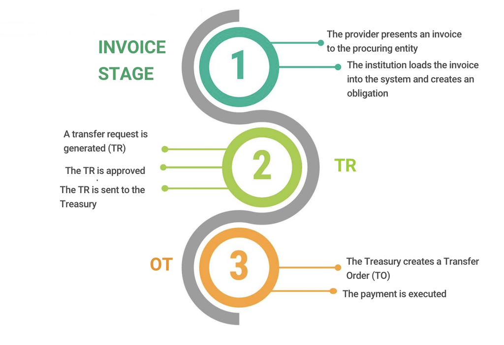

## Data

- **Data of the contracting procedure**
- **Invoice data**
- **Institutional data**
- Period: 2011-2017

The final dataset had 315.973 observations + 61.537 observations with extreme values.

## Survival analysis

Survival analysis is a statistical method used to analyze and model the data when the outcome variable is the time until the occurrence of a specific event. In our case, the event of interest is the **date of payment of an invoice**.

We also estimated the effect of covariates in payment time.

## Cost estimation

\(C = P * i * d\)

where,

C= estimated cost for firms  
P=amount of each payment in guaranies  
i= annual average lending rate  
d= delay expressed as a fraction of a year

We adjusted by inflation using the GDP deflator (2017=100) and used the 2017 average exchange rate.

## Limitations

- Lack of exact invoice due date
- Information about the providers
- Institutional data availability

## Results

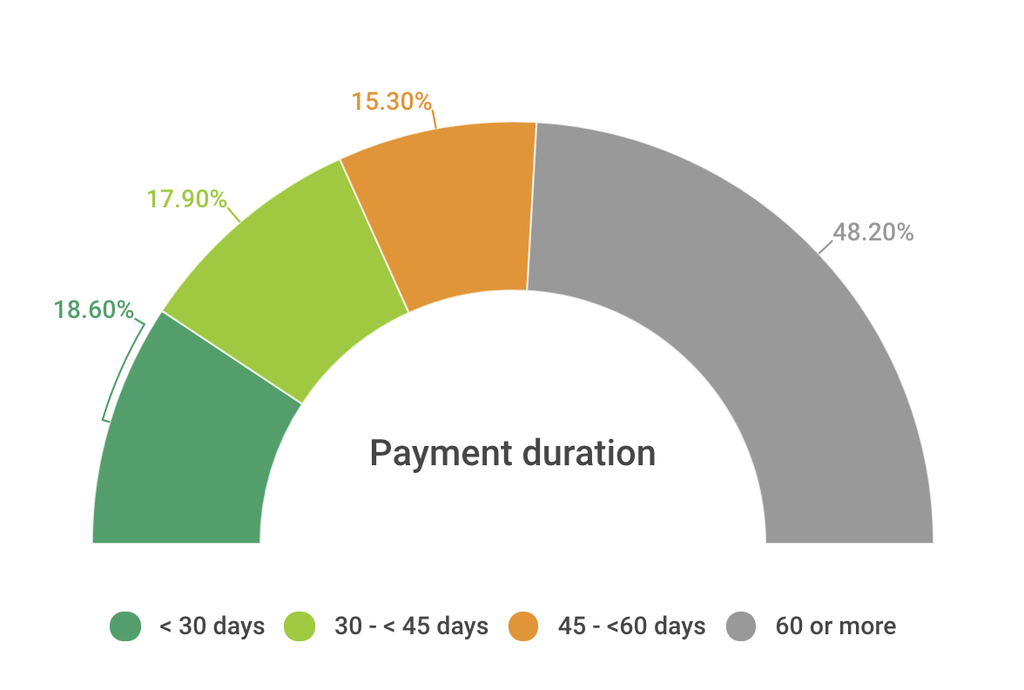

## Results

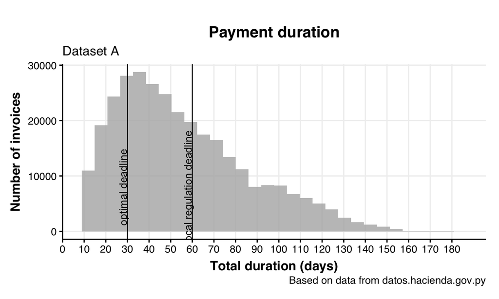

## Results

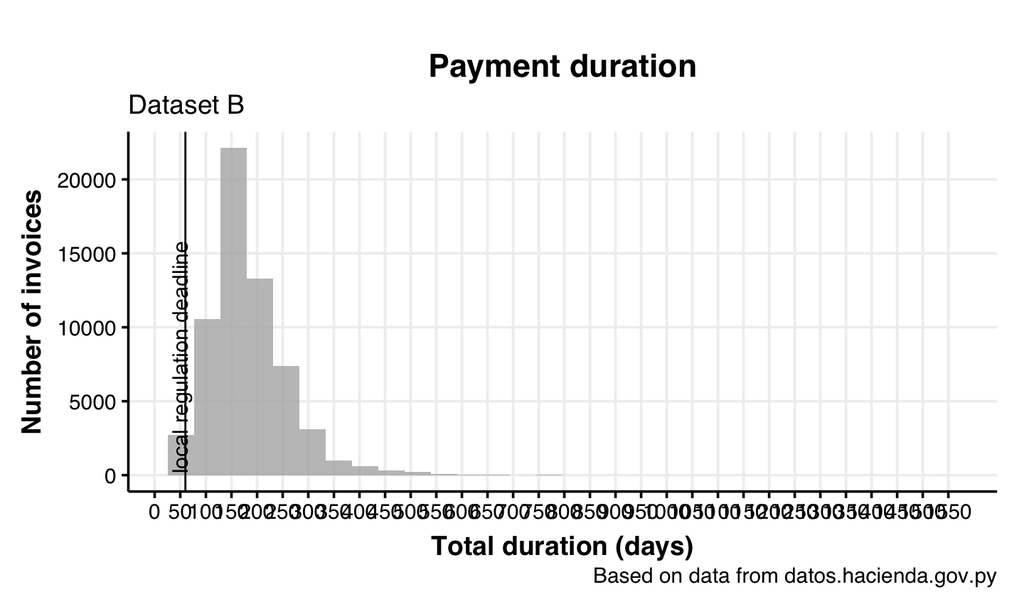

## Duration by year and stage

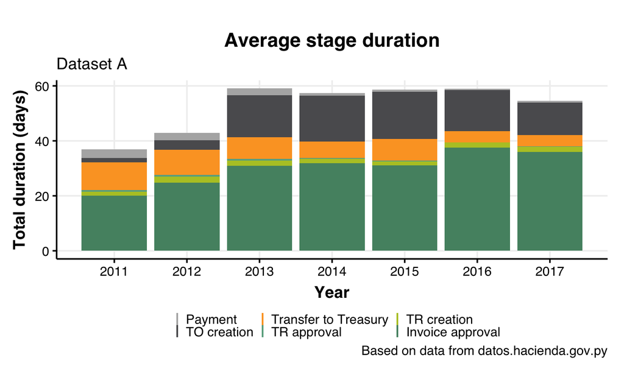

## Duration by institution

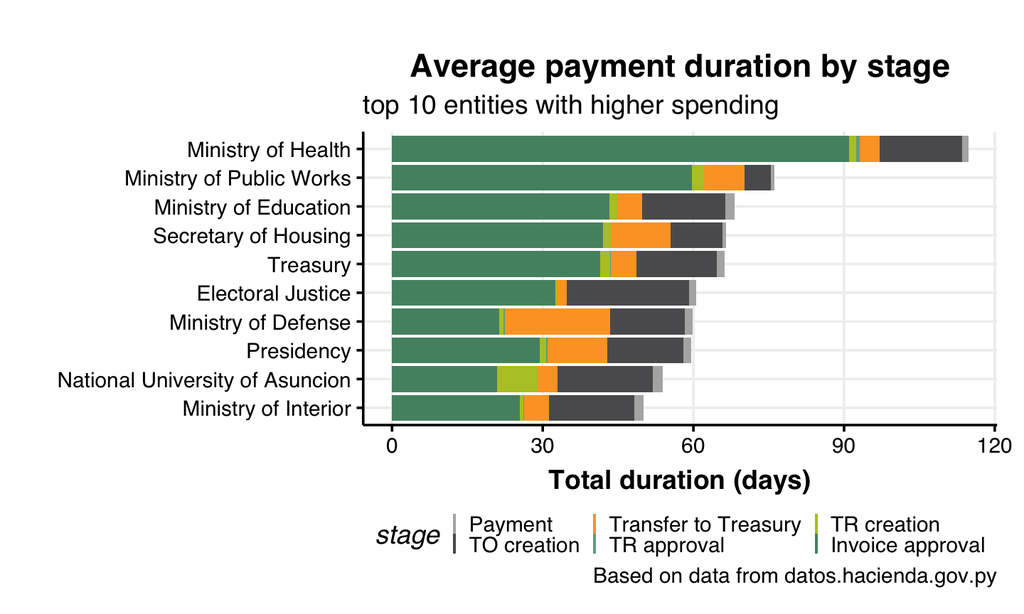

## By type of funds

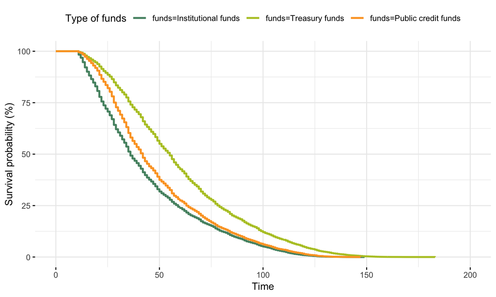

## Funds and stages

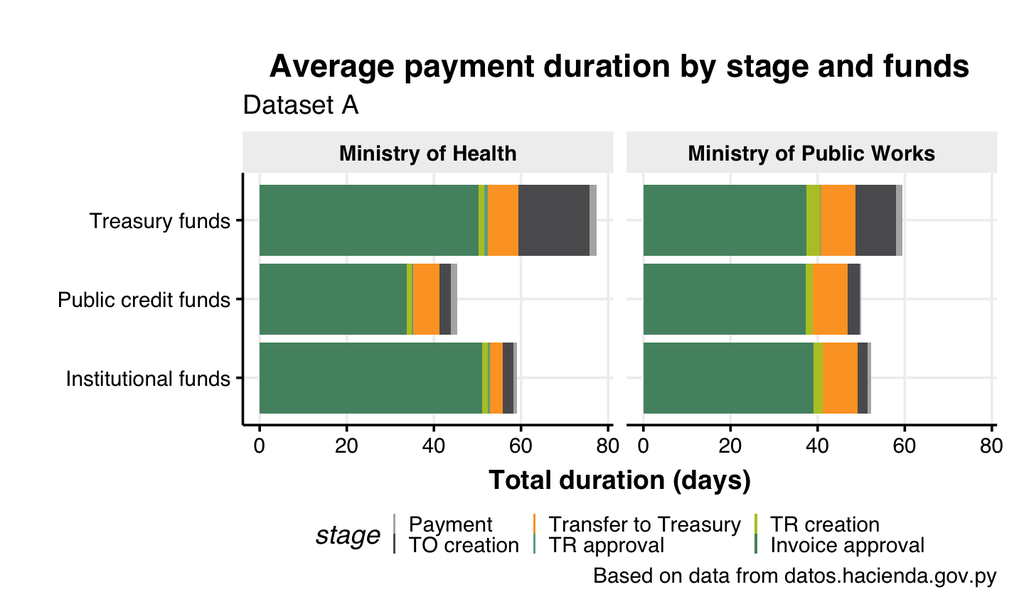

## Seasonal trends

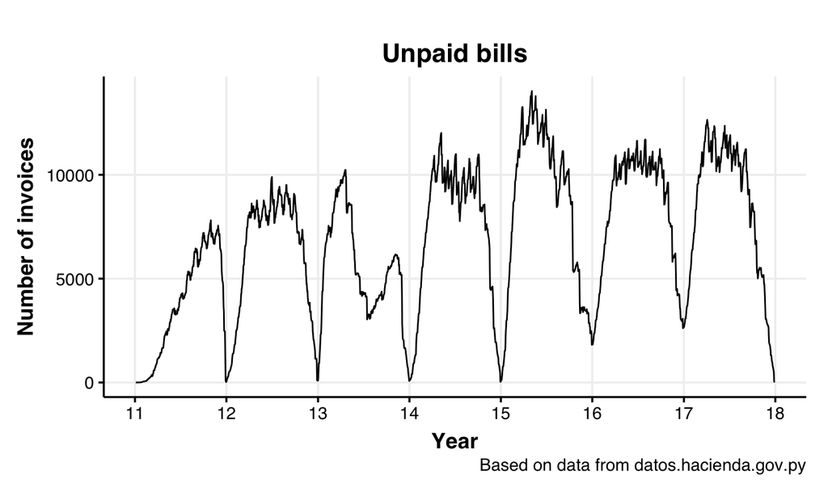

## Results for the survival model

- A one percent increase in the invoice amount shortens survival time by 0.97 times, this means that larger invoices are paid faster.
- Using Treasury funds to pay the invoice, increases survival time (payment takes longer) by 1.31 times in comparison to using institutional or Public credit funds.
- Institutions with more than 10,000 employees extends survival time by 1.43 times in comparison to smaller entities with a payroll of less than 1,000.
- Invoices related to services purchases are paid faster than purchases for investment or goods and materials.

## Cost estimation

Between 2011 and 2017, the total cost of late payments was of **$142.29 million** (0.48% of 2017 nominal GDP).

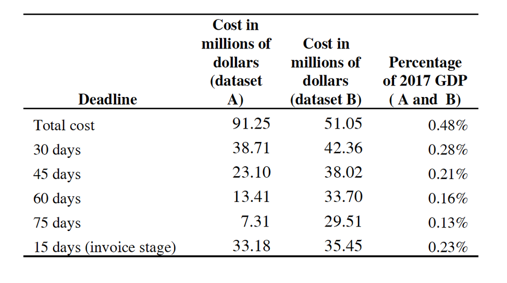

## Cost by year

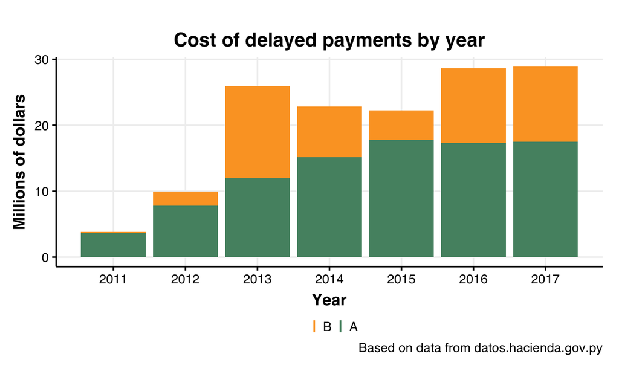

## By stage

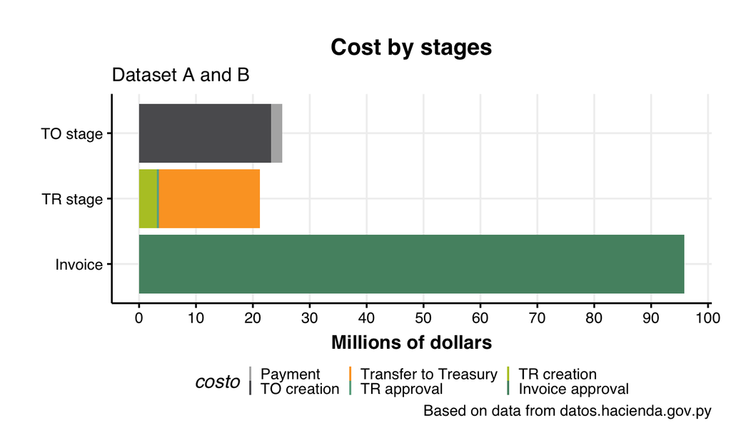

## Cost by institution

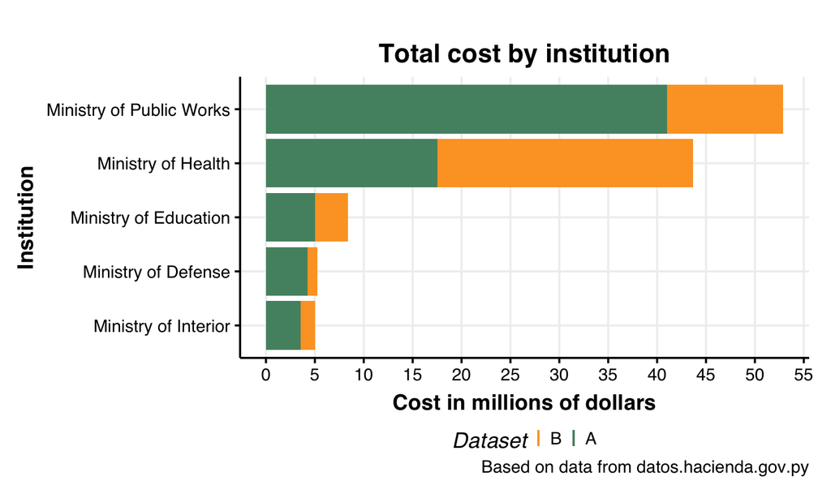